# assignment 3: data visualization

Koray Poyraz

10/5/2021

loading libraries

```r
library(tidyverse)
library(lubridate)
```

## Applying Peng’s checklist

load Bakery data as csv

```r
df_bakery <- read_csv('data/Bakery.csv')
```

view variable names

```r
names(df_bakery)
```

```
## [1] "TransactionNo" "Items"         "DateTime"      "Daypart"
## [5] "DayType"
```

check packaging

```r
str(df_bakery)
```

```
## spec_tbl_df [20,507 × 5] (S3: spec_tbl_df/tbl_df/tbl/data.frame)
##  $ TransactionNo: num [1:20507] 1 2 2 3 3 3 4 5 5 5 ...
##  $ Items        : chr [1:20507] "Bread" "Scandinavian" "Scandinavian" "Hot chocolate" ...
##  $ DateTime     : POSIXct[1:20507], format: "2016-10-30 09:58:11" "2016-10-30 10:05:34" ...
##  $ Daypart      : chr [1:20507] "Morning" "Morning" "Morning" "Morning" ...
##  $ DayType      : chr [1:20507] "Weekend" "Weekend" "Weekend" "Weekend" ...
##  - attr(*, "spec")=
##   .. cols(
##   ..   TransactionNo = col_double(),
##   ..   Items = col_character(),
##   ..   DateTime = col_datetime(format = ""),
##   ..   Daypart = col_character(),
##   ..   DayType = col_character()
##   .. )
```

top and bottom

```r
head(df_bakery)
```

```
## # A tibble: 6 x 5
##   TransactionNo Items         DateTime            Daypart DayType
##           <dbl> <chr>         <dttm>              <chr>   <chr>
## 1             1 Bread         2016-10-30 09:58:11 Morning Weekend
## 2             2 Scandinavian  2016-10-30 10:05:34 Morning Weekend
## 3             2 Scandinavian  2016-10-30 10:05:34 Morning Weekend
## 4             3 Hot chocolate 2016-10-30 10:07:57 Morning Weekend
## 5             3 Jam           2016-10-30 10:07:57 Morning Weekend
## 6             3 Cookies       2016-10-30 10:07:57 Morning Weekend
```

```r
tail(df_bakery)
```

```
## # A tibble: 6 x 5
##   TransactionNo Items        DateTime            Daypart   DayType
##           <dbl> <chr>        <dttm>              <chr>     <chr>
## 1          9682 Tacos/Fajita 2017-09-04 14:32:58 Afternoon Weekend
## 2          9682 Coffee       2017-09-04 14:32:58 Afternoon Weekend
## 3          9682 Tea          2017-09-04 14:32:58 Afternoon Weekend
## 4          9683 Coffee       2017-09-04 14:57:06 Afternoon Weekend
## 5          9683 Pastry       2017-09-04 14:57:06 Afternoon Weekend
## 6          9684 Smoothies    2017-09-04 15:04:24 Afternoon Weekend
```

check your n’s

```r
# These N checks are done to get a understanding of the attributes count

# check N by Items
df_bakery %>% count(Items)
```

```
## # A tibble: 94 x 2
##    Items                        n
##    <chr>                    <int>
##  1 Adjustment                   1
##  2 Afternoon with the baker    44
##  3 Alfajores                  369
##  4 Argentina Night              7
##  5 Art Tray                    38
##  6 Bacon                        1
##  7 Baguette                   152
##  8 Bakewell                    48
##  9 Bare Popcorn                 5
## 10 Basket                       6
## # … with 84 more rows
```

```r
# check N by Daypart, amount sales per Daypart
df_bakery %>% count(Daypart)
```

```
## # A tibble: 4 x 2
##   Daypart       n
##   <chr>     <int>
## 1 Afternoon 11569
## 2 Evening     520
## 3 Morning    8404
## 4 Night        14
```

```r
# check N by DayType, amount sales per DayType
df_bakery %>% count(DayType)
```

```
## # A tibble: 2 x 2
##   DayType     n
##   <chr>   <int>
## 1 Weekday 12807
## 2 Weekend  7700
```

```r
# check N by Date, amount sales per date
df_bakery %>%
  mutate(Date=as.Date(DateTime)) %>%
  count(Date)
```

```
## # A tibble: 159 x 2
##    Date           n
##    <date>     <int>
##  1 2016-01-11   150
##  2 2016-01-12    83
##  3 2016-02-11   164
##  4 2016-02-12   104
##  5 2016-03-11   189
##  6 2016-03-12   191
##  7 2016-04-11   187
##  8 2016-04-12   121
##  9 2016-05-11   275
## 10 2016-05-12   117
## # … with 149 more rows
```

check missing values

```r
# check if any column has any missing value
amount_nas <- df_bakery %>%
  select_if(function(x) any(is.na(x)))

str_c('There are: ', length(amount_nas), ' missing values')
```

```
## [1] "There are: 0 missing values"
```

simple plot to get a idea of the data

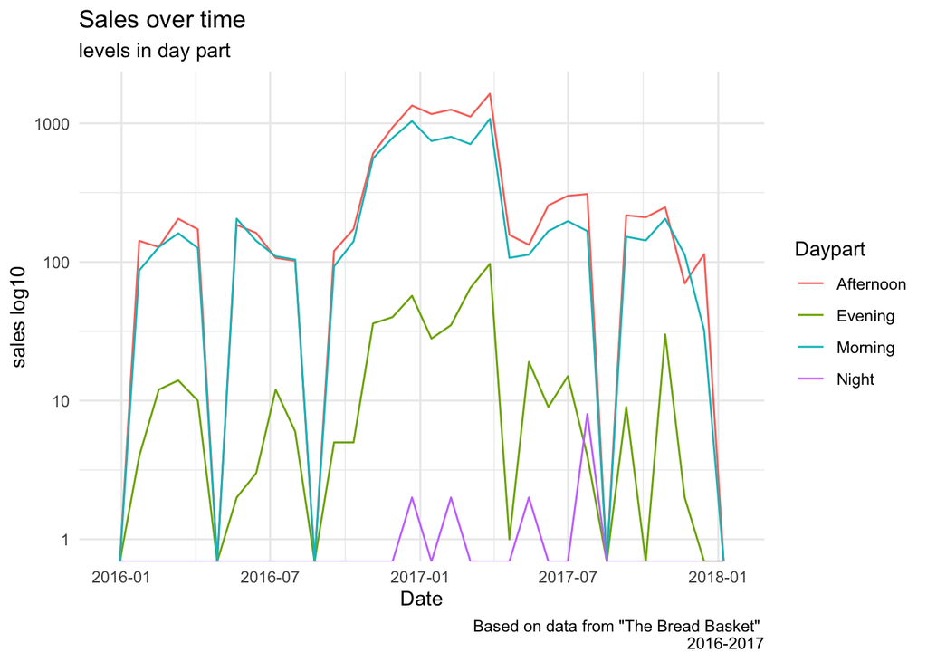

```r
df_bakery %>%
  mutate(Date=as.Date(DateTime)) %>%
  ggplot(aes(Date)) +
  geom_freqpoly(aes(color=Daypart), bins=30) +
  theme_minimal() +
  scale_y_log10() +
  labs(
    title='Sales over time',
    subtitle = 'levels in day part',
    y='sales log10',
    caption='Based on data from "The Bread Basket" \n 2016-2017')
```

preperation for good visualization

```r
# The idea here is to get a insight in the sales during weekdays and hours over time

# a new tibble with 2 new variables, wday (week day) and hour
df_bakery_wday <- df_bakery %>%
  arrange(DateTime) %>%
  mutate(wday = wday(DateTime, label = TRUE, week_start=1, abbr=FALSE, locale='en_GB'),
         hour = hour(DateTime))

# display tibble
df_bakery_wday
```

```
## # A tibble: 20,507 x 7
##    TransactionNo Items  DateTime            Daypart DayType wday    hour
##            <dbl> <chr>  <dttm>              <chr>   <chr>   <ord>  <int>
##  1           178 Coffee 2016-01-11 07:51:20 Morning Weekday Monday     7
##  2           178 Pastry 2016-01-11 07:51:20 Morning Weekday Monday     7
##  3           179 Coffee 2016-01-11 08:20:50 Morning Weekday Monday     8
##  4           179 Pastry 2016-01-11 08:20:50 Morning Weekday Monday     8
##  5           180 Jam    2016-01-11 08:22:28 Morning Weekday Monday     8
##  6           180 Tea    2016-01-11 08:22:28 Morning Weekday Monday     8
##  7           181 Tea    2016-01-11 08:45:20 Morning Weekday Monday     8
##  8           181 Tea    2016-01-11 08:45:20 Morning Weekday Monday     8
##  9           182 Pastry 2016-01-11 09:07:47 Morning Weekday Monday     9
## 10           182 Pastry 2016-01-11 09:07:47 Morning Weekday Monday     9
## # … with 20,497 more rows
```

analyzing the max and min in hour

```r
# display the max and min tuples of hour to get a view for filtering
max_hour <- max(df_bakery_wday$hour)
min_hour <- min(df_bakery_wday$hour)

rbind(
  df_bakery_wday[which.max(df_bakery_wday$hour),],
  df_bakery_wday[which.min(df_bakery_wday$hour),]
  )
```

```
## # A tibble: 2 x 7
##   TransactionNo Items           DateTime            Daypart DayType wday    hour
##           <dbl> <chr>           <dttm>              <chr>   <chr>   <ord>  <int>
## 1          6588 Valentine's ca… 2017-02-14 23:29:03 Night   Weekday Tuesd…    23
## 2          4090 Bread           2017-01-01 01:21:05 Morning Weekend Sunday     1
```

```r
# as the company switched to online shopping, people make also orders in the evening
df_bakery_wday %>%
  filter(between(hour, 20, max_hour)) %>%
  arrange(desc(hour))
```

```
## # A tibble: 36 x 7
##    TransactionNo Items         DateTime            Daypart DayType wday     hour
##            <dbl> <chr>         <dttm>              <chr>   <chr>   <ord>   <int>
##  1          6588 Valentine's … 2017-02-14 23:29:03 Night   Weekday Tuesday    23
##  2          6589 Valentine's … 2017-02-14 23:38:41 Night   Weekday Tuesday    23
##  3          9648 Vegan Feast   2017-08-04 23:20:54 Night   Weekend Friday     23
##  4          9448 Juice         2017-05-04 22:15:55 Night   Weekday Thursd…    22
##  5          9448 Mineral water 2017-05-04 22:15:55 Night   Weekday Thursd…    22
##  6          9638 Vegan Feast   2017-08-04 22:41:09 Night   Weekend Friday     22
##  7          9640 Vegan Feast   2017-08-04 22:43:06 Night   Weekend Friday     22
##  8          9641 Vegan Feast   2017-08-04 22:45:51 Night   Weekend Friday     22
##  9          9642 Scandinavian  2017-08-04 22:47:27 Night   Weekend Friday     22
## 10          9643 Vegan Feast   2017-08-04 22:48:52 Night   Weekend Friday     22
## # … with 26 more rows
```

```r
# here we see a strange online order at 1:21 am, because I dont have much info on opening hours and delivery I can not say much but it is somehow funny to order a bread at 1:21 am
# I have chosen not to visualize 1 record (online order at 1:21:05 am), which is reported as the 1st row in the tibble below. The reason is to have a more fine visualized plot and because this concerns 1 record, it is fine to have it reported.
df_bakery_wday %>%
  filter(between(hour, min_hour, 10)) %>%
  arrange(hour)
```

```
## # A tibble: 5,302 x 7
##    TransactionNo Items     DateTime            Daypart DayType wday     hour
##            <dbl> <chr>     <dttm>              <chr>   <chr>   <ord>   <int>
##  1          4090 Bread     2017-01-01 01:21:05 Morning Weekend Sunday      1
##  2           178 Coffee    2016-01-11 07:51:20 Morning Weekday Monday      7
##  3           178 Pastry    2016-01-11 07:51:20 Morning Weekday Monday      7
##  4           340 Coffee    2016-03-11 07:46:50 Morning Weekday Friday      7
##  5           340 Bread     2016-03-11 07:46:50 Morning Weekday Friday      7
##  6           341 Medialuna 2016-03-11 07:50:50 Morning Weekday Friday      7
##  7           341 Medialuna 2016-03-11 07:50:50 Morning Weekday Friday      7
##  8           437 Medialuna 2016-04-11 07:32:33 Morning Weekday Monday      7
##  9          1275 Coffee    2016-11-14 07:39:27 Morning Weekday Monday      7
## 10          1342 Coffee    2016-11-15 07:42:27 Morning Weekday Tuesday     7
## # … with 5,292 more rows
```

## Good visualization

### info:

- geom = bars/ rectangle
- mapping = x maps hour, y maps count of occurrences, fill in Daypart (level)
- position = dodge, bin width = 1 (equal to 1 hour) and border color = white
- facet = wday (week day)
- theme = minimal
- scale = continuous, scale_y_sqrt (Straightening)

### explanation:

- geom: I chose for histogram so I can distribute the count of occurrences in bins of 1 hour with having Daypart as a fill color (categorical: color hue, ‘Tamara Munzer’) in dodge position (T1, less log error in ‘Tamara Munzer’) (‘Michael Friendly’ distinction of color, day parts) which gives the possibility to group the hours and day parts together for a better perceiving and quick understanding of the data (decode)
- border color: I chose for white so the observer can get a better feeling of the distribution over the hours and it makes the visualization less harsh
- facet: I found the subplots in week day necessary so the eye of the observer can travel much smoother. So the observer can get more detail of a certain day.
- theme: I found the minimal fashion a good taste (High Data/ Ink, ‘Tufte wisdom’), it takes away the noise
- y label: I chose to not use it because the heights of the bars already give a certain understanding of the sales
- scale: here I used straightening for y-axis (Tukey) so we can have better view of some day parts, e.g. Night and Evening

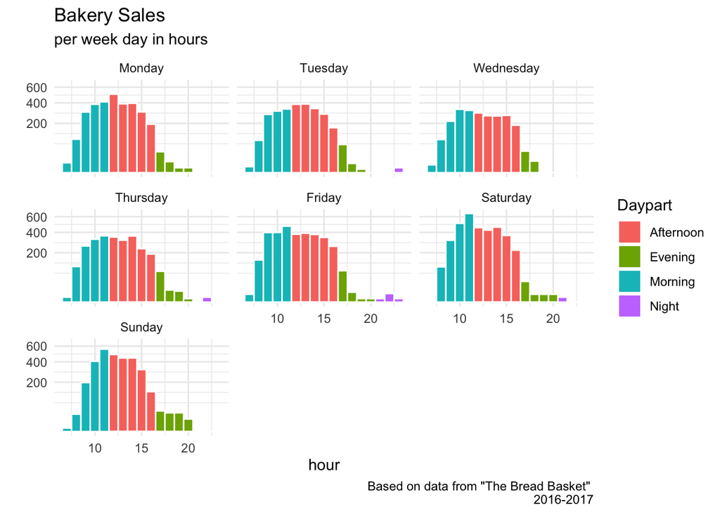

```r
# Question: what are the hours of the week days that deliver high sales?

df_bakery_wday %>%
  filter(hour > 1) %>%
  ggplot(aes(hour, fill=Daypart), position='dodge') +
  geom_histogram(binwidth = 1, color='white') +
  facet_wrap(vars(wday)) +
  theme_minimal() +
  scale_y_sqrt() +
  labs(
    title='Bakery Sales',
    subtitle = 'per week day in hours',
    x='hour',
    y='',
    caption='Based on data from "The Bread Basket" \n 2016-2017')
```

## Bad visualization

### info:

- geom = points, dots
- mapping = x maps counts, y maps Items
- stat = identity
- color = static ‘red’
- theme = manual inputs

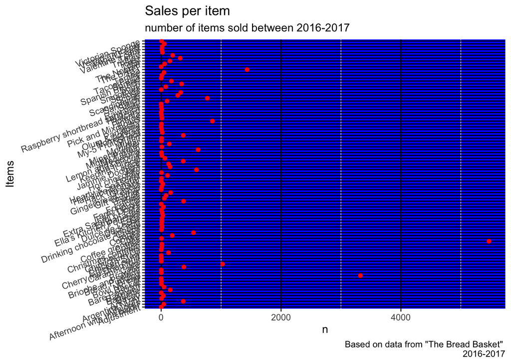

```r
# Question: how many items were sold between 2016 and 2017?

df_bakery %>%
  count(Items) %>%
  ggplot(aes(n, Items)) +
  geom_point(color='red', show.legend = FALSE) +
  theme(
    axis.text.y=element_text(angle=20),
    panel.background = element_rect(fill = 'blue'),
    panel.grid.major = element_line(colour = "black"),
    panel.border = element_rect(linetype = 0, fill = NA)) +
  labs(title = "Sales per item", subtitle = 'number of items sold between 2016-2017', caption='Based on data from "The Bread Basket" \n 2016-2017')
```